# USS & BOLT R-WORKSHOP 2021

**Welcome to the R Workshop! Our goal today is to introduce you to Data Science and Statistics in R!**

# What is Data Science?

Data Science combines the fields of Computer Science, Mathematics and Statistics to create insights and make sense of data in a meaningful way. It is a key part of every industry now a days!

Examples of Data Science in the real world:

- Predicting malignant breast cancer tumours through machine learning
- Self driving cars
- Supply chain optimization for companies such as Amazon to shorten delivery time
- Targetting ads based off user behaviour on websites

## What is R?

R is a programming language developed by statisticians. It was designed specifically for data analysis and has many useful libraries great for data wrangling, analysis, visualization, and machine learning.

Now Jasper will introduce you to R Studio

First we are going to load a package into R. Tidyverse is a popular package used for data science. To load any installed package, use the function library(package name). If you have not already installed it, you can install it via install.packages("tidyverse")

```r
# load package


library(tidyverse)
```

Next, we are going to be loading our dataset into R. If you are ever looking for open source datasets to practice, check out Kaggle.com.

```r
# Load data
df <- read_csv("Student_Performance.csv")
```

```
* `` -> ...1
```

This is useful when your dataset is large

```r
head(df, 3)
```

A tibble: 3 × 9

| ...1 <dbl> | race/ethnicity <chr> | parental level of education <chr> | lunch <chr> | test preparation course <chr> | math percentage <dbl> | reading score percentage <dbl> | writing score percentage <dbl> | sex <chr> |
| --- | --- | --- | --- | --- | --- | --- | --- | --- |
| 0 | group B | bachelor's degree | standard | none | 0.72 | 0.72 | 0.74 | F |
| 1 | group C | some college | standard | completed | 0.69 | 0.90 | 0.88 | F |
| 2 | group B | master's degree | standard | none | 0.90 | 0.95 | 0.93 | F |

How would you check the last 4 rows of the dataset? Go ahead and write the code for this!

hint: ...(df, ...)

```r
tail(df, 4)
```

Often times there are missing values in a dataset. Lets check using the following snippet of code:

```r
any(is.na(df))
```

FALSE

If there are missing values, it returns TRUE, otherwise FALSE like we see here.

Sometimes the column names are not easy to understand. Or they include spaces which is harder to work with.

R, like many other programming languages gives columns an index. R uses a one-based index. An easy way to rename columns uses indexing, so lets look at our dataframe to see the index of each column again.

```r
head(df, 2)
```

Now we can rename columns using the names function and the column index. For example, Parental education level has index = 3

```r
# rename columns

names(df)[3] <- "parent_edu_level"
names(df)[5] <- "test_prep_course"
names(df)[6] <- "math_score"
names(df)[7] <- "reading_score"
names(df)[8] <- "writting_score"
```

```r
# look at df again

head(df, 2)
```

Discuss with your neighbour reasons why renaming columns may be very important

To get values in a column, we can use indexing or the following syntax:

```r
df[6]
```

```r
as_tibble(df$lunch)
```

Lets do some exploratory analysis! Question: How can we look at the relationship between math score and reading score?

Scatterplots are used to compare 2 variables, to see if there may be a relationship between them. ggplot2 is a great package for data visualization. Fill in the ... in the following code to create a scatterplot:

```r
# this is the syntax for ggplot scatterplots

#  ggplot(df, aes(x= ... , y= ...)) +
#         geom_point()
```

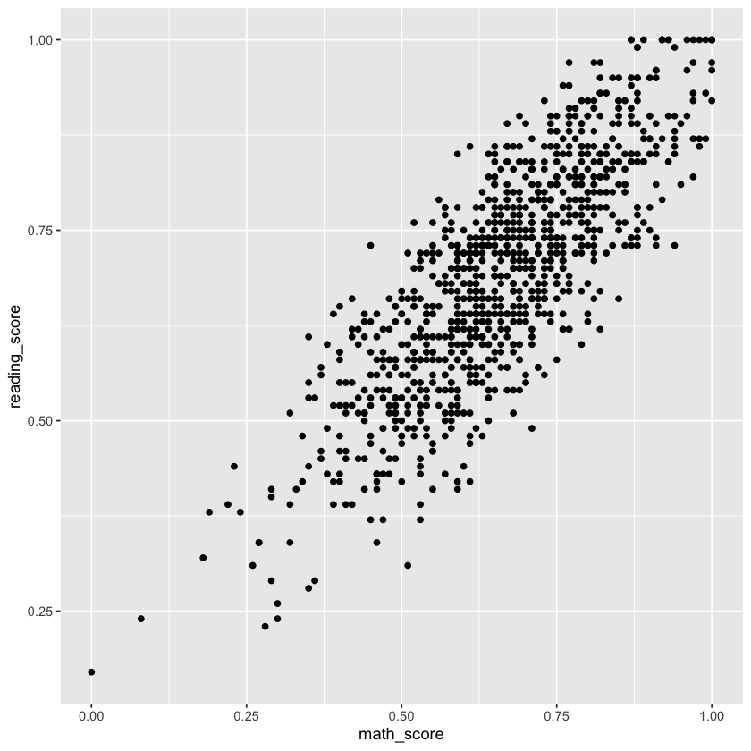

```r
ggplot(df, aes(x= math_score, y=reading_score)) +
        geom_point()
```

Q: Based on the plot, can you tell if there is a relationship between the two variables, and if so what type?

To visualize a categorical variable and a continous variable we can use side by side bar plots, using geom_col instead of geom_point. Lets look at Parent Education Level and Math score.

```r
head(df, 6)
```

How can we calculate the average of each parental education level separately?

Lets use the pipe operator %>%, and the functions group_by and summarize. %>% is used to apply a sequence of functions

```r
# calculate summary statisitcs

df_math <- df %>% group_by(parent_edu_level) %>%
    summarize(av_math_score = mean(math_score))
```

```r
# another example calculating median via summarize

df_math_median <- df %>% group_by(parent_edu_level) %>%
    summarize(median_math_score = median(math_score))

df_math_median
```

A tibble: 6 × 2

| parent_edu_level <chr> | median_math_score <dbl> |
| --- | --- |
| associate's degree | 0.670 |
| bachelor's degree | 0.680 |
| high school | 0.630 |
| master's degree | 0.730 |
| some college | 0.675 |
| some high school | 0.650 |

Now we can finally make our bar graph! I am also changing the titles of the axis's here. With ggplot you can add layers to change things such as the titles.

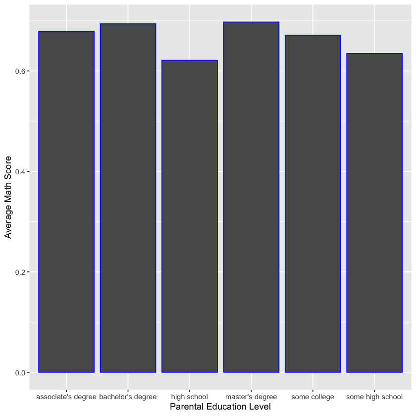

```r
ggplot(df_math, aes(x=parent_edu_level, y=av_math_score)) +
    labs(x="Parental Education Level", y="Average Math Score")+
    geom_col( color="blue")
```

You can also calculate summary statistics for each column individually! some useful functions are: mean(), sd(), filter() and median()

What if we want to look at just women? We can use filter() Fill in the blank in the code below!

```r
df_F <- df %>% filter(sex == "F")
head(df_F, 5)
```

Exercise: Lets look at the relationship between test preparation and reading score! Use what we just learned to create a bar graph of the median reading score for each category of test preparation. Feel free to ask questions if you need help!

One more visualization tool! You can add more layers to ggplots that do special things. What if we wanted to make a scatterplot to show the relationship between reading and writting score, based on whether or not not they took the prep course

```r
#  ggplot(iris_small, aes(x=...,y=...)) +

#  geom_point() +

#  facet_wrap(~...)
```

Based on the above template, figure out what goes in the ... to make a scatterplot to show the relationship between reading and writting score, based on whether or not not they took the prep course

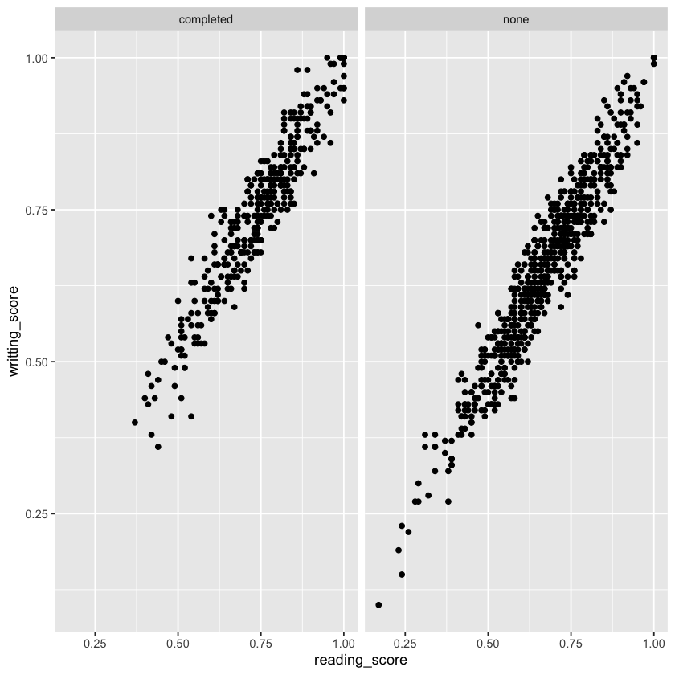

```r
ggplot(df, aes(x=reading_score,y=writting_score)) + geom_point() +
    facet_wrap(~test_prep_course)
```

What do the scatterplots show us?

We can see that their is a strong positive linear relationship between reading scores and writting scores.

We can also see that the lowest scores were people with no test prep course

Since there is a strong linear relationship here, can we use someones reading score to predict writting score?

Lets fit a linear model! R has a built in function lm()

```r
# simple linear regression model

reg <- lm(writting_score ~ reading_score, data=df)
```

Simple linear regression minimizes the sum of squares of prediction error to get the least square regression line

minimize $\Sigma(y_{i} - b_{0} - b_{1}x)^2$

$\hat{y} = b_{0} + b_{1}x_{i}$

$b_{0}$ is the intercept $b_{1}$ is the coefficient learned by the model

we can use the summary(reg) to look at our model

```r
summary(reg)
```

```
Call:
lm(formula = writting_score ~ reading_score, data = df)

Residuals:
      Min        1Q    Median        3Q       Max
-0.129573 -0.029573  0.000363  0.031026  0.150557

Coefficients:
               Estimate Std. Error t value Pr(>|t|)
(Intercept)   -0.006676   0.006938  -0.962    0.336
reading_score  0.993531   0.009814 101.233   <2e-16 ***
---
Signif. codes:  0 ‘***’ 0.001 ‘**’ 0.01 ‘*’ 0.05 ‘.’ 0.1 ‘ ’ 1

Residual standard error: 0.04529 on 998 degrees of freedom
Multiple R-squared:  0.9113,	Adjusted R-squared:  0.9112
F-statistic: 1.025e+04 on 1 and 998 DF,  p-value: < 2.2e-16
```

How can we tell if our model is good?

- look at R^2 value

$R^2$ represents the percentage of the variance of the response variable that can be explained by the predictor variables of our model. It is a measure of how good our regression line fits the data.

perfect $R^2$ value is 1

```r
summary(reg)$r.squared
```

0.911257488891314

Wow! Since this is very close to 1, it means our model is a good fit

What if we want to add in more predictor varibles? Can R handle categorical variables such as test_prep_course ?

```r
reg2 <- lm(writting_score ~ reading_score + test_prep_course, data=df)
```

```r
summary(reg2)
```

```
Call:
lm(formula = writting_score ~ reading_score + test_prep_course,
    data = df)

Residuals:
      Min        1Q    Median        3Q       Max
-0.140906 -0.030140  0.000179  0.028745  0.130800

Coefficients:
                      Estimate Std. Error t value Pr(>|t|)
(Intercept)           0.026254   0.007528   3.487 0.000509 ***
reading_score         0.971577   0.009702 100.139  < 2e-16 ***
test_prep_coursenone -0.027639   0.002953  -9.359  < 2e-16 ***
---
Signif. codes:  0 ‘***’ 0.001 ‘**’ 0.01 ‘*’ 0.05 ‘.’ 0.1 ‘ ’ 1

Residual standard error: 0.04344 on 997 degrees of freedom
Multiple R-squared:  0.9184,	Adjusted R-squared:  0.9183
F-statistic:  5612 on 2 and 997 DF,  p-value: < 2.2e-16
```

For binary variables, R uses one as a baseline, which is why we only see test_prep_coursenone above.

How do we know if a coefficient is important?

1. does adding it increase adjusted R^2 value?
2. is it significant?

We know whether a coeefficient is significant by looking at it's p-value in the summary output.

Test: $H_{0}$: coefficient = 0 vs $H_{a}$: coefficient $\neq$ 0

Test statistic: $\frac{B_{i}-\beta_{i}}{se(B_{i})}$ ~ $t_{n-k}$

Thankfully R does this for us! Look at the P(>|t|) in the summary ouput for significance! We see that all the coefficients are significant at alpha=0.001.

```r
summary(reg2)
```

```
Call:
lm(formula = writting_score ~ reading_score + test_prep_course,
    data = df)

Residuals:
      Min        1Q    Median        3Q       Max
-0.140906 -0.030140  0.000179  0.028745  0.130800

Coefficients:
                      Estimate Std. Error t value Pr(>|t|)
(Intercept)           0.026254   0.007528   3.487 0.000509 ***
reading_score         0.971577   0.009702 100.139  < 2e-16 ***
test_prep_coursenone -0.027639   0.002953  -9.359  < 2e-16 ***
---
Signif. codes:  0 ‘***’ 0.001 ‘**’ 0.01 ‘*’ 0.05 ‘.’ 0.1 ‘ ’ 1

Residual standard error: 0.04344 on 997 degrees of freedom
Multiple R-squared:  0.9184,	Adjusted R-squared:  0.9183
F-statistic:  5612 on 2 and 997 DF,  p-value: < 2.2e-16
```

Your turn! Create a linear model for the response variable math_score, start with one predictor variable, and then add more and see if it makes your model stronger!

# Thank you for participating in our workshop! Questions?